# Distances & Ordination: BIOME Worshop

## Phyloseq: Distances and Ordination

`distance` + `ordinate` + `plot_ordination` =

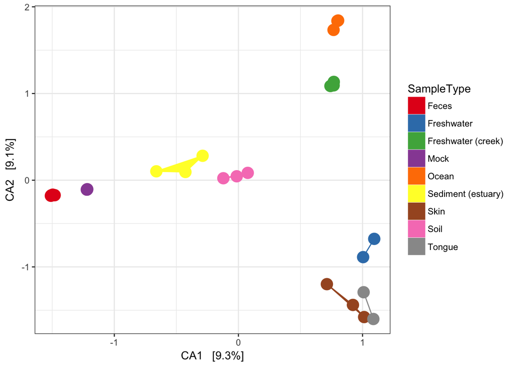

## The `distance` function

The `distance` function implements a wide varity of community distance and dissimilarity metrics.

```r
library(phyloseq); packageVersion("phyloseq")
```

```
## [1] '1.25.2'
```

```r
unlist(distanceMethodList)
```

```
##     UniFrac1     UniFrac2        DPCoA          JSD     vegdist1
##    "unifrac"   "wunifrac"      "dpcoa"        "jsd"  "manhattan"
##     vegdist2     vegdist3     vegdist4     vegdist5     vegdist6
##  "euclidean"   "canberra"       "bray" "kulczynski"    "jaccard"
##     vegdist7     vegdist8     vegdist9    vegdist10    vegdist11
##      "gower"   "altGower"   "morisita"       "horn"  "mountford"
##    vegdist12    vegdist13    vegdist14    vegdist15   betadiver1
##       "raup"   "binomial"       "chao"        "cao"          "w"
##   betadiver2   betadiver3   betadiver4   betadiver5   betadiver6
##         "-1"          "c"         "wb"          "r"          "I"
##   betadiver7   betadiver8   betadiver9  betadiver10  betadiver11
##          "e"          "t"         "me"          "j"        "sor"
##  betadiver12  betadiver13  betadiver14  betadiver15  betadiver16
##          "m"         "-2"         "co"         "cc"          "g"
##  betadiver17  betadiver18  betadiver19  betadiver20  betadiver21
##         "-3"          "l"         "19"         "hk"        "rlb"
##  betadiver22  betadiver23  betadiver24        dist1        dist2
##        "sim"         "gl"          "z"    "maximum"     "binary"
##        dist3   designdist
##  "minkowski"        "ANY"
```

For the most part these are implemented in other packages, especially vegan via `vegdist` and `betadiver` functions, but a few important ones are implemented directly in phyloseq, including the unifrac distances and DPCoA.

Note: Other packages also define functions named `distance`, so sometimes it is best to specify the phyloseq one specifically by `phyloseq::distance`.

## The `distance` function

When you call the `distance` function, it will calculate the community distances/dissimilarities between all samples in the phyloseq object.

```r
data(GlobalPatterns); GP <- GlobalPatterns # for shorthand
GP5 <- prune_samples(sample_names(GP)[1:5], GP)
dist5 <- distance(GP5, method="jsd")
dist5
```

```
##               CL3       CC1       SV1   M31Fcsw
## CC1     0.2547080
## SV1     0.5051481 0.4378036
## M31Fcsw 0.6809263 0.6863213 0.6848186
## M11Fcsw 0.6813418 0.6869444 0.6850675 0.2864774
```

The standard object returned is of class `"dist"`, but can also be converted into a (symmetric) matrix.

```r
as(dist5, "matrix")
```

```
##               CL3       CC1       SV1   M31Fcsw   M11Fcsw
## CL3     0.0000000 0.2547080 0.5051481 0.6809263 0.6813418
## CC1     0.2547080 0.0000000 0.4378036 0.6863213 0.6869444
## SV1     0.5051481 0.4378036 0.0000000 0.6848186 0.6850675
## M31Fcsw 0.6809263 0.6863213 0.6848186 0.0000000 0.2864774
## M11Fcsw 0.6813418 0.6869444 0.6850675 0.2864774 0.0000000
```

## The `ordinate` function

The `ordinate` function implements several methods to convert a set of community distances/dissimilarities into a reduced dimentionsal representation.

Supported methods include: `c("DCA", "CCA", "RDA", "CAP", "DPCoA", "NMDS", "MDS", "PCoA")`, with `"NMDS"` (non-metric multi-dimenstional scaling) and `"MDS"` (multidimensional scaling) being probably the most commonly used in practice.

```r
ord5 <- ordinate(GP5, method="MDS", distance=dist5)
ord5
```

```
## $correction
## [1] "none" "1"
##
## $note
## [1] "There were no negative eigenvalues. No correction was applied"
##
## $values
##   Eigenvalues Relative_eig Broken_stick Cumul_eig Cumul_br_stick
## 1  0.47078225   0.69173622    0.5208333 0.6917362      0.5208333
## 2  0.13991537   0.20558237    0.2708333 0.8973186      0.7916667
## 3  0.04103500   0.06029412    0.1458333 0.9576127      0.9375000
## 4  0.02884797   0.04238730    0.0625000 1.0000000      1.0000000
##
## $vectors
##             Axis.1      Axis.2        Axis.3       Axis.4
## CL3     -0.2579732  0.18754350  0.0009915435  0.108387165
## CC1     -0.2797596  0.09544320 -0.0009414947 -0.128077000
## SV1     -0.2119769 -0.30871094  0.0001109519  0.025987313
## M31Fcsw  0.3745886  0.01307078 -0.1433165115 -0.002340825
## M11Fcsw  0.3751211  0.01265346  0.1431555108 -0.003956653
##
## $trace
## [1] 0.6805806
##
## attr(,"class")
## [1] "pcoa"
```

There is also a shorthand in which you directly specify the distance method, rather than precomputing it.

```r
ord5.short <- ordinate(GP5, method="MDS", distance="jsd")
identical(ord5, ord5.short)
```

```
## [1] TRUE
```

## The `ordinate` function: Dimensionality

Roughly speaking, the `$Eigenvalues` list the importance of each dimension in explaining the total set of distances, and it is often worth performing a scree plot to get a sense of the dimensionality of the data.

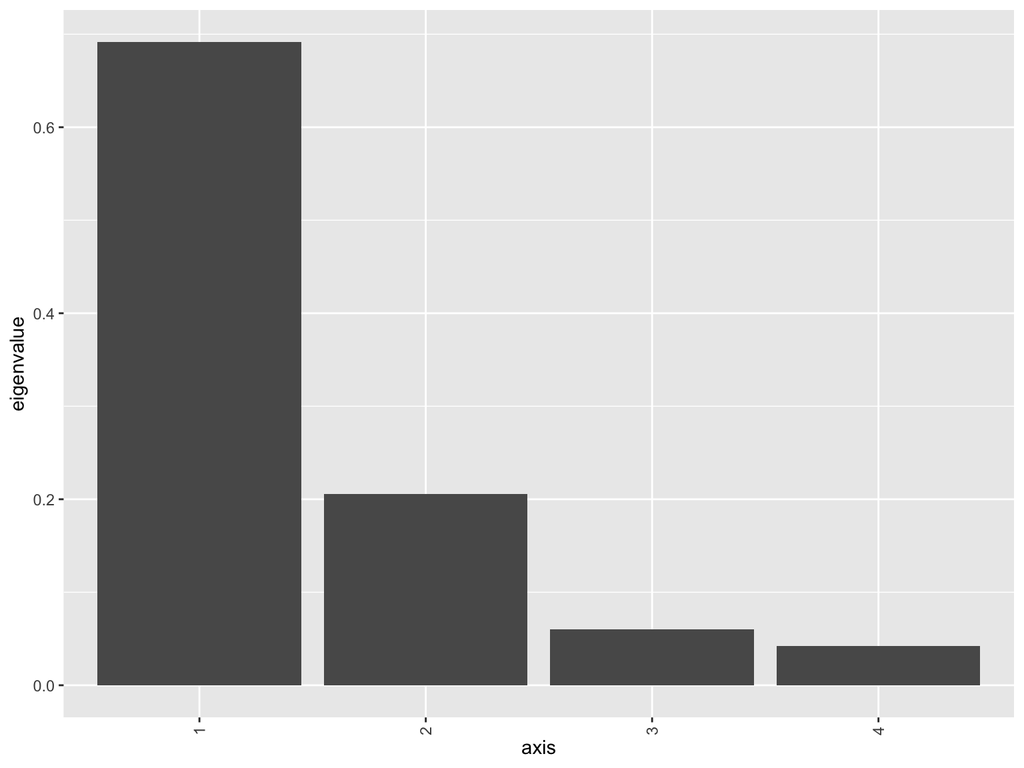

```r
plot_scree(ord5)
```

Here we see that the first dimension explains much of the data, and the second some, while the 3rd/4th dimensions contribute very little. This gives us a qualitative sense of the dimensional complexity of the distance/dissimilarity relationships, and is often worth inspecting.

## The `plot_ordination` function

In the end, we want those pretty graphics. The function to do that is the `plot_ordination` function, which produces ggplot2 graphics (which are then infinitely further modifiable via ggplot2). `plot_ordination` requires a phyloseq object, and an ordination that was produces from that object. It also allows simple assignment of color, shape, label and size to sample variables.

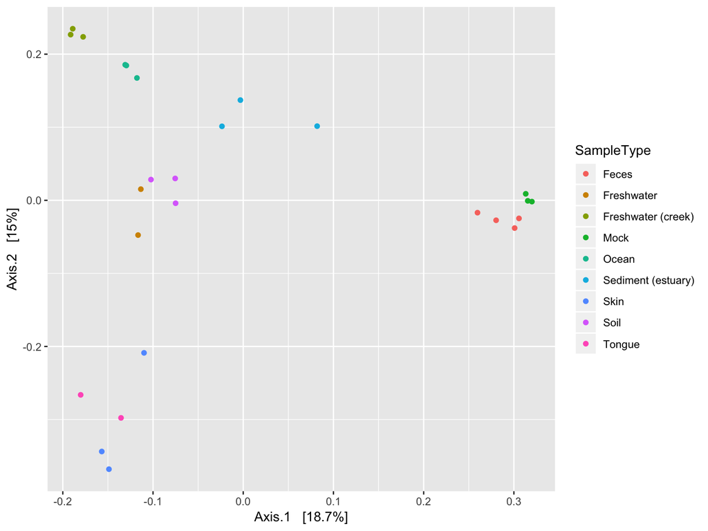

```r
ord <- ordinate(GP, method="MDS", distance="jsd")
plot_ordination(GP, ord, color="SampleType")
```

Much more information is available from `?plot_ordination` and also through [the `plot_ordination` tutorial on the phyloseq web site](https://joey711.github.io/phyloseq/plot_ordination-examples.html).